# Assignment3: Supervised Learning Competition - Group 11

Authors

Lourenço Santos Moitinho de Almeida

Liam Thomassen

Tim Rentenaar

Erdem Koçer

Published

October 22, 2023

## Data Description & Data Exploration

In order to predict student performance using the various characteristics of the students, we begin our analysis by exploring our dataset. Our exploratory data analysis will roughly follow the guidelines stated by Tukey and Peng. With that said, in order to get a preliminary understanding of our data, we ran the `str()` command as shown below in *Table 1*:

**Table 1:** Checking the Packaging of the Dataset using `str()`

```r
str(train_data)
```

```
tibble [316 × 31] (S3: tbl_df/tbl/data.frame)
 $ school    : Factor w/ 2 levels "GP","MS": 1 1 1 1 1 1 1 1 1 1 ...
 $ sex       : Factor w/ 2 levels "F","M": 1 1 2 2 1 1 2 1 1 2 ...
 $ age       : num [1:316] 18 17 17 18 16 15 15 15 16 15 ...
 $ address   : Factor w/ 2 levels "U","R": 1 1 1 2 1 2 1 1 1 1 ...
 $ famsize   : Factor w/ 2 levels "GT3","LE3": 1 1 1 1 1 2 2 1 1 1 ...
 $ Pstatus   : Factor w/ 2 levels "A","T": 2 2 2 2 2 2 2 2 2 2 ...
 $ Medu      : num [1:316] 3 3 2 4 1 2 3 4 3 2 ...
 $ Fedu      : num [1:316] 2 4 3 3 3 2 3 4 3 3 ...
 $ Mjob      : Factor w/ 5 levels "at_home","health",..: 3 4 3 5 1 2 3 4 3 3 ...
 $ Fjob      : Factor w/ 5 levels "teacher","other",..: 3 2 2 3 3 3 2 5 2 2 ...
 $ reason    : Factor w/ 4 levels "course","other",..: 2 1 1 1 3 4 1 1 3 3 ...
 $ guardian  : Factor w/ 3 levels "mother","father",..: 1 1 2 1 1 1 1 1 1 1 ...
 $ traveltime: num [1:316] 1 1 2 1 1 2 1 1 1 1 ...
 $ studytime : num [1:316] 3 3 1 3 2 2 2 3 3 3 ...
```

[output cut: 17 more lines]

```r
factor_cols <- names(train_data)[sapply(train_data, is.factor)]
num_cols <- names(train_data)[sapply(train_data, is.numeric)]
```

This training dataset contains 316 rows and 31 columns. Furthermore, the column `score` represents our dependent variable while the rest of the columns are explanatory variables. This dataset contains two types of variables: factor (categorial) and numerical variables. Each column can be categorized into one of the two variables types:

- Factor Variables: school, sex, address, famsize, Pstatus, Mjob, Fjob, reason, guardian, schoolsup, famsup, paid, activities, nursery, higher, internet, romantic
- Numerical Variables: age, Medu, Fedu, traveltime, studytime, failures, famrel, freetime, goout, Dalc, Walc, health, absences, score

Additionally, *Figure 1* dispalys that this dataset doesn’t contain any missing values. Therefore, any missing information imputation strategies won’t be required during the data (pre)processing step of our analysis.

**Figure 1:** Counts of all the Missing Data per Column

```r
sapply(train_data, function(x) sum(is.na(x)))
```

```
    school        sex        age    address    famsize    Pstatus       Medu
         0          0          0          0          0          0          0
      Fedu       Mjob       Fjob     reason   guardian traveltime  studytime
         0          0          0          0          0          0          0
  failures  schoolsup     famsup       paid activities    nursery     higher
         0          0          0          0          0          0          0
  internet   romantic     famrel   freetime      goout       Dalc       Walc
         0          0          0          0          0          0          0
    health   absences      score
         0          0          0
```

An important thing to note is that despite the insights given by running the `str()` command, reading the column descriptions file gives contradicting information. For instance out of the 14 numeric columns, only `age`, `absences` and `score` are ‘true’ numericcal variables. The rest of the variables are ordinal variables such as `Dalc`, a variable ranging from 1-5 based on workday alcohol consumption. This assessment is further backed up by analysing the top and bottom of the dataset as shown below in *Table 2* and *Table 3*:

**Table 2:** Top of the Dataset

```r
head(train_data)
```

| school | sex | age | address | famsize | Pstatus | Medu | Fedu | Mjob | Fjob | reason | guardian | traveltime | studytime | failures | schoolsup | famsup | paid | activities | nursery | higher | internet | romantic | famrel | freetime | goout | Dalc | Walc | health | absences | … |
| --- | --- | --- | --- | --- | --- | --- | --- | --- | --- | --- | --- | --- | --- | --- | --- | --- | --- | --- | --- | --- | --- | --- | --- | --- | --- | --- | --- | --- | --- | --- |
| GP | F | 18 | U | GT3 | T | 3 | 2 | other | services | other | mother | 1 | 3 | 0 | no | no | no | no | yes | yes | yes | yes | 5 | 4 | 3 | 2 | 3 | 1 | 7 | … |
| GP | F | 17 | U | GT3 | T | 3 | 4 | services | other | course | mother | 1 | 3 | 0 | no | no | no | no | yes | yes | yes | no | 4 | 4 | 5 | 1 | 3 | 5 | 16 | … |
| GP | M | 17 | U | GT3 | T | 2 | 3 | other | other | course | father | 2 | 1 | 0 | no | no | no | no | yes | yes | yes | no | 5 | 2 | 2 | 1 | 1 | 2 | 4 | … |
| GP | M | 18 | R | GT3 | T | 4 | 3 | teacher | services | course | mother | 1 | 3 | 0 | no | no | no | no | yes | yes | yes | yes | 5 | 3 | 2 | 1 | 2 | 4 | 9 | … |
| GP | F | 16 | U | GT3 | T | 1 | 3 | at_home | services | home | mother | 1 | 2 | 3 | no | no | no | yes | no | yes | yes | yes | 4 | 3 | 5 | 1 | 1 | 3 | 0 | … |
| GP | F | 15 | R | LE3 | T | 2 | 2 | health | services | reputation | mother | 2 | 2 | 0 | yes | yes | yes | no | yes | yes | yes | no | 4 | 1 | 3 | 1 | 3 | 4 | 2 | … |

**Table 3:** Bottom of the Dataset

```r
tail(train_data)
```

| school | sex | age | address | famsize | Pstatus | Medu | Fedu | Mjob | Fjob | reason | guardian | traveltime | studytime | failures | schoolsup | famsup | paid | activities | nursery | higher | internet | romantic | famrel | freetime | goout | Dalc | Walc | health | absences | … |
| --- | --- | --- | --- | --- | --- | --- | --- | --- | --- | --- | --- | --- | --- | --- | --- | --- | --- | --- | --- | --- | --- | --- | --- | --- | --- | --- | --- | --- | --- | --- |
| GP | F | 17 | U | GT3 | T | 4 | 2 | other | other | reputation | mother | 2 | 3 | 0 | no | yes | yes | no | yes | yes | yes | no | 4 | 3 | 3 | 1 | 1 | 3 | 0 | … |
| GP | M | 15 | R | GT3 | T | 4 | 3 | teacher | at_home | course | mother | 1 | 2 | 0 | no | yes | no | yes | yes | yes | yes | yes | 4 | 5 | 2 | 1 | 1 | 5 | 0 | … |
| GP | M | 17 | U | LE3 | T | 4 | 4 | other | teacher | home | father | 2 | 1 | 0 | no | no | yes | no | yes | yes | yes | no | 4 | 1 | 1 | 2 | 2 | 5 | 0 | … |
| GP | M | 16 | U | GT3 | T | 4 | 4 | services | services | other | mother | 1 | 1 | 0 | yes | yes | yes | yes | yes | yes | yes | no | 4 | 5 | 5 | 5 | 5 | 4 | 14 | … |
| MS | F | 17 | R | GT3 | T | 3 | 1 | at_home | other | reputation | mother | 1 | 2 | 0 | no | yes | yes | yes | no | yes | yes | no | 4 | 5 | 4 | 2 | 3 | 1 | 17 | … |
| GP | F | 15 | U | GT3 | T | 4 | 4 | teacher | health | reputation | mother | 1 | 2 | 0 | no | yes | yes | no | yes | yes | yes | no | 3 | 3 | 3 | 1 | 2 | 2 | 0 | … |

### The Analysis for the Dependent Variable: Score

```r
minimum_value <- round(min(train_data$score), 2)
maximum_value <- round(max(train_data$score), 2)
median_value <- round(median(train_data$score), 2)
q1_value <- round(quantile(train_data$score, 0.25), 2)
q3_value <- round(quantile(train_data$score, 0.75), 2)
```

The whole aim of this analysis is to predict scores for students in the test dataset. In order to do so we took a closer look at the variable `score`. Below, *Figure 2* displays the spread of `score` in addition to a 5-number summary. Following the inter-quartile range rule for outlier detection, scores outside the range of $-2.535\leq x \leq 2.545$ would be considered outliers.

**Figure 2:** The Spread and 5-Number Summary of Score

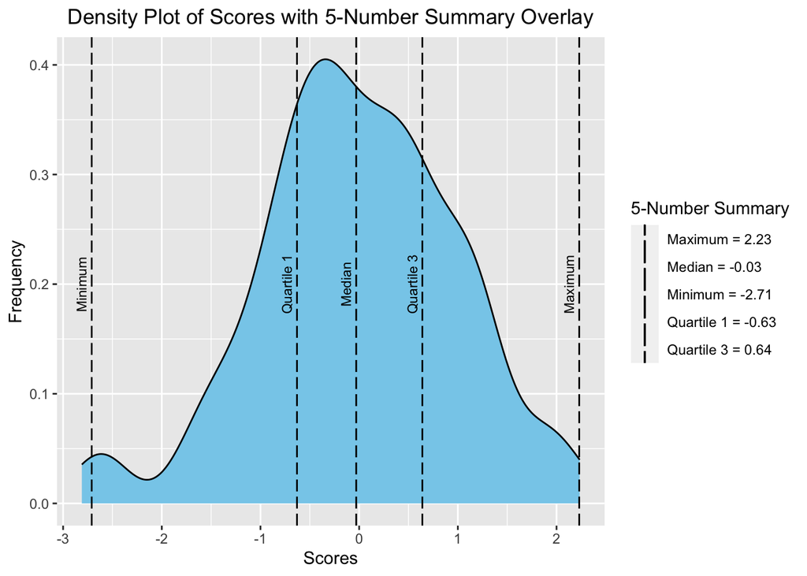

```r
ggplot(train_data, aes(x = score)) +
  geom_density(fill = "skyblue") +
  xlab("Scores") +
  ylab("Frequency") +
  ggtitle("Density Plot of Scores with 5-Number Summary Overlay") +
  theme(plot.title = element_text(hjust = 0.5)) +

  geom_vline(aes(xintercept = minimum_value, color = "Minimum = -2.71"), linetype = "longdash") +
  annotate(geom = "text", label = "Minimum", color = "black", angle = 90, x = minimum_value-0.1, y = 0.2, size = 3) +

  geom_vline(aes(xintercept = maximum_value, color = "Maximum = 2.23"), linetype = "longdash") +
  annotate(geom = "text", label = "Maximum", color = "black", angle = 90, x = maximum_value-0.1, y = 0.2, size = 3) +

  geom_vline(aes(xintercept = median_value, color = "Median = -0.03"), linetype = "longdash") +
  annotate(geom = "text", label = "Median", color = "black", angle = 90, x = median_value-0.1, y = 0.2, size = 3) +

  geom_vline(aes(xintercept = q1_value, color = "Quartile 1 = -0.63"), linetype = "longdash") +
  annotate(geom = "text", label = "Quartile 1", color = "black", angle = 90, x = q1_value-0.1, y = 0.2, size = 3) +

  geom_vline(aes(xintercept = q3_value, color = "Quartile 3 = 0.64"), linetype = "longdash") +
  annotate(geom = "text", label = "Quartile 3", color = "black", angle = 90, x = q3_value-0.1, y = 0.2, size = 3) +

  scale_color_manual("5-Number Summary", values = c("Minimum = -2.71" = "black", "Maximum = 2.23" = "black", "Median = -0.03" = "black", "Quartile 1 = -0.63" = "black", "Quartile 3 = 0.64" = "black"))
```

### Correlation between Score and the Explanatory Variables

For the correlation between `score` and the rest of the explanatory variables we divided the training dataset by variable type. *Table 4* displays the correlation between the numerical variables. The variables `failures`, `goout` and `age` measuring the student’s number of past class failures, time spent with friend and age seemed to have the greatest negative correlation against `score` while `Medu` and `Fedu`, variables measuring their parent’s education seemed to have the greatest positive correlation. Additionally, `goout` and `Dalc` (workday alcohol consumption) are both positively correlated with `Walc` (weekend alcohol consumption). In contrast, *Table 5* displays the correlation between the converted dummy categorical variables and `score`. Although, none of the categorical variables seemed to be correlated with `score`. The only strongly correlated variables in this table were between the categories of `Mjob` and `Fjob` (variables that measure the parent’s occupation).

**Table 4:** Correlation Matrix between Numerical Variables and Score

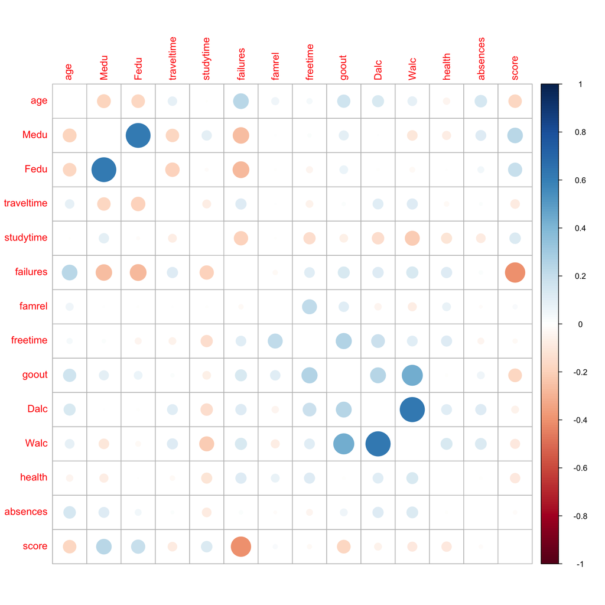

```r
corrplot(cor(train_data[sapply(train_data, is.numeric)]), diag = FALSE)
```

**Table 5:** Correlation Matrix between Converted Categorical Variables and Score

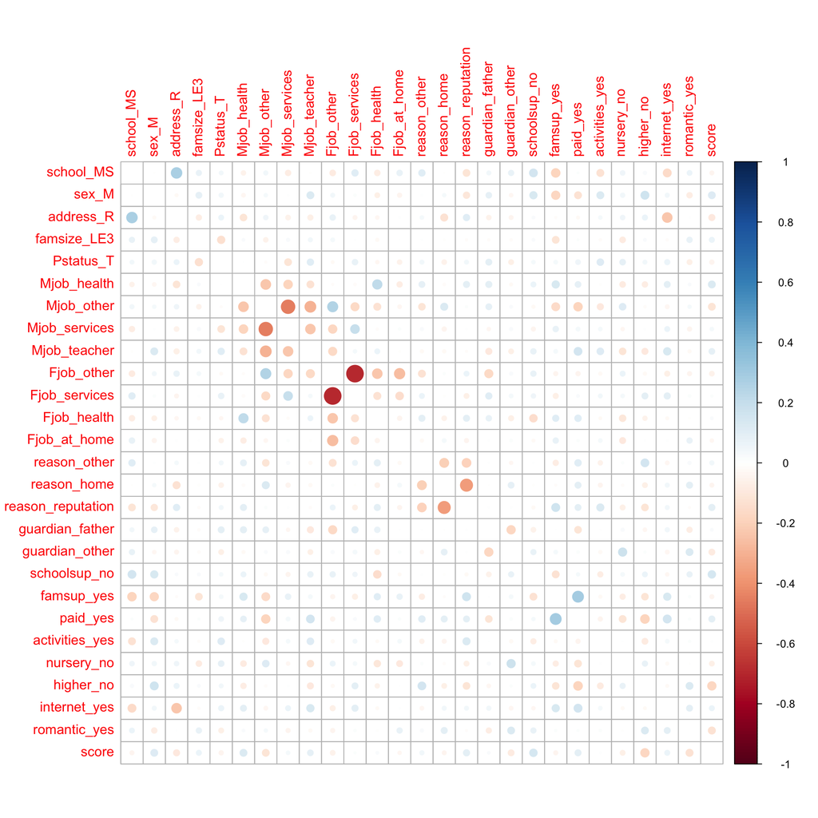

```r
temp_df <- train_data[, !sapply(train_data, is.numeric)]
temp_df_dummy <- dummy_cols(temp_df,remove_first_dummy=TRUE,remove_selected_columns=TRUE)
temp_df_dummy$score <- train_data$score

corrplot(cor(temp_df_dummy), diag = FALSE)
```

## Model Descriptions

For our analysis we implemented five fundamental supervised learning algorithms that encompassed nine different models in total.

**0. Trivial Baseline - Mean**

Even though we don’t consider this technique a model we included a trivial baseline in order to compare our model’s results with a basic prediction. In our case we decided to take the mean `score` from the training data and apply it to the dev data.

**1. K-Nearest Neighbors (KNN)** - 1.1 KNN: K-Nearest Neighbors is a non-paramtric algorithm that is mainly aimed towards classification however it can also be applied towards regression tasks. Similarly to the trivial baseline, we expected that the KNN model would under perform in comparison to the other models explained below. Despite this reasoning, we decided to include the model for comparison evlauations in addition to the relatively easy implementation of it.

**2. Regression** - 2.1 Linear Regression: Similarly to the KNN model, we chose to include a linear regression model in order to compare and evaluate our more complex models against it.

- 2.2 Lasso Regression: Lasso regression is very similar to linear regression. The difference between the two models is that the lasso model includes regularization and feature selection. This model decreases coefficients towards zero which is ideal for datasets with an increased amount of explanatory variables. The regularization technique aims to decrease the likelihood of over fitting the model.
- 2.3 Generalized Additive Models (GAM): In contrast to the linear and lasso regression models above, the GAM model aims to analyze linear and non-linear relationships. Due to the variation of data types in our dataset, the GAM model allows for more flexibility at the cost of increasing model complexity.

**3. Neural Networks** - 3.1 and 3.2 Simple and Complex Neural Network: Neural networks are complex machine learning algorthims that are able to be implemented towards more complex tasks such as modeling non-linear relationships and image recognition. Although one of the advantages of this model stems from its versatility and scalabilty, it comes at a cost of increasing the computation cost and over fitting the data. For our analysis, we implemented two neural networks that differed in complexity. The main difference between the two models used were the amount of activation layers included in the model.

**4. Ensemble Methods** - 4.1 XGBoost: XGBoost is an ensemble methods of ‘weak learners’ that implements gradient boosting. This tree-based model trains decision trees on different subsets of the data that aim to improve the residual of the model. In order to get a prediction, XGBoost combines this set of ‘weak learners’ in order to improve it prediction capabilities.

- 4.2 Mixed Model - XGBoost and Lasso Regression Unlike the previous models discussed, the mixed model combines the lasso and XGBoost model together rather than implementing a new algorithm. The aim of this model is to improve prediction capability through the regularization used in lasso regression in conjunction to XGBoost’s ability of combining sets of weak learners. This combination implicitly implements feature selection due to the fact that lasso regularization decreases the weights of each coefficient while the tree-based model creates subsets of ‘weak learners’ that correct based on the results from the previous decision tree in the sequence.

**5. Support Vector Machine (SVM)** - 5.1 SVM The SVM model (or SVR for regression) aims to analyze the data and create some type of model that slightly deviates from the actual data. The prediction created by this model aim to fall within a certain threshold. Much like the previous models discussed, this model is able to analyze non-linear relationships and is less sensitive towards outliers.

## Data Transformation and Pre-processing

### Data Transformation

```r
train_dummy <- dummy_cols(train_data, remove_selected_columns = TRUE)
test_dummy <- dummy_cols(test_data, remove_selected_columns = TRUE)
```

### Data Reduction

After dummy encoding the categorical variables in our dataset we decided not to remove any explanatory variables from our prediction model equations. Instead, we chose to implement machine learning models that excelled at handing high dimensional datasets such as Lasso regression and the GAM model. Furthermore, based on our correlation analysis, we concluded that data reduction wasn’t required either.

### Data Cleaning

From the information gathered from exploring the dataset, we didn’t identify any missing data. Therefore, missing data imputation strategies were not used for our analysis. Furthermore, we didn’t find any significant ‘noisy’ or outlier data points in our dataset. Additionally, the regression models handle these potential issues by smoothing the data into regression functions

## Model Exploration and Comparison

### Model Training

- Creation of the K-fold Cross Validation:

```r
train_control <- trainControl(method="cv", number=5)
```

- Creation of the Train/Dev 80-20 Random Split:

```r
sample_size <- floor(0.8 * nrow(train_dummy))

set.seed(1)
train_index <- sample(seq_len(nrow(train_dummy)), size=sample_size)

train_dummy_train <- train_dummy[train_index,]
train_dummy_dev <- train_dummy[-train_index,]
```

### Model Implementation

For our model we decided to use the techniques of K-fold cross validation and a train/dev split. For K-fold cross validation we implemented it on the models of linear regression, a neural network and KNN. As for the train/dev split we decided to implement it on lasso regression, XGBoost, SVM, GAM, the mixed model and on a simple and more complex neural network.

#### Model Implementation using K-fold Cross Validation

**K-Nearest Neighbors (KNN)**

```r
# training knn using k-fold crossvalidation
#knn <- train(score ~ ., data=train_dummy, method="knn", trControl=train_control)
```

```r
#print(knn)
```

**Linear Regression**

```r
# training a linear model using k-fold crossvalidation
#lm <- train(score ~ ., data=train_dummy, method="lm", trControl=train_control)
```

```r
# resulting scores (including MAE) from linear regression
#print(lm)
```

**Neural Networks (using k-fold)**

```r
# training a model averaged neural network using k-fold crossvalidation
#nn <- train(score ~ ., data=train_dummy, method="avNNet", trControl=train_control)
```

```r
#print(nn)
```

#### Model Implementation using a Train/Dev Split

```r
X_train <- train_dummy_train[, -which(names(train_dummy_train) == "score")]
y_train <- data.frame(train_dummy_train$score)
X_test <- train_dummy_dev[, -which(names(train_dummy_dev) == "score")]
y_test <- train_dummy_dev$score
```

**Trivial Baseline - Mean**

```r
# creating a mean trivial baseline is not possible with the caret package
# the mean trivial baseline will be created with a single train/dev split

mean_score_train <- mean(train_dummy_train$score)
```

```r
# resulting MAE and MSE from the trivial baseline
mae <- mean(abs(train_dummy_dev$score - mean_score_train))
mse <- mean((train_dummy_dev$score - mean_score_train) ** 2)

print(mae)
```

```
[1] 0.7483624
```

```r
print(mse)
```

```
[1] 0.8831195
```

**Lasso Regression**

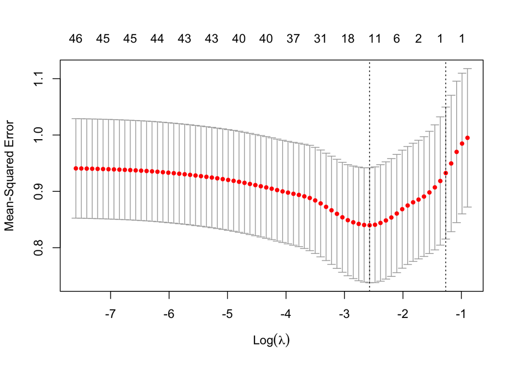

```r
original_weights <- rep(1, nrow(X_train))

cv_model <- cv.glmnet(data.matrix(X_train), data.matrix(y_train), alpha = 1)

best_lambda <- cv_model$lambda.min
best_model <- glmnet(data.matrix(X_train), data.matrix(y_train), alpha = 1, lambda = best_lambda)
plot(cv_model)
```

```r
pred_y_lasso <- predict(best_model, s = best_lambda, newx = data.matrix(X_test))
cat("mse of lasso model: ", mean((as.matrix(pred_y_lasso)-as.matrix(y_test))^2))
```

```
mse of lasso model:  0.714799
```

**Generalized Additive Models (GAM)**

```r
gam_model <- gam(score ~ s(age,k=3) +
                   s(failures, k=4) +
                   s(studytime, k = 4) +
                   internet_no +
                   sex_M +
                   famsize_GT3 +
                   Dalc +
                   Walc +
                   Pstatus_A +
                   reason_reputation,
                 data = train_dummy_train)

testing_data <- data.frame(X_test)

pred_y_gam <- predict(gam_model, newdata = testing_data)
cat("mse of GAM model: ", mean((as.matrix(pred_y_gam)-as.matrix(y_test))^2))
```

```
mse of GAM model:  0.7236812
```

**Simple Neural Network (using Train/Dev)**

```r
model <- keras_model_sequential() %>%
    layer_dense(16, activation = 'relu') %>%
    layer_dropout(0.1) %>%
    layer_dense(8, activation = 'relu') %>%
    layer_dropout(0.1) %>%
    layer_dense(1)

model %>% compile(
  loss = 'mean_absolute_error',
  optimizer = optimizer_adam()
)

plot_model <- model %>% fit(as.matrix(X_train),
      as.matrix(y_train),
      epochs = 100,
      validation_split = 0.1,
      verbose = 0)

pred_y_nn <- predict(model, as.matrix(X_test))
```

```
2/2 - 0s - 72ms/epoch - 36ms/step
```

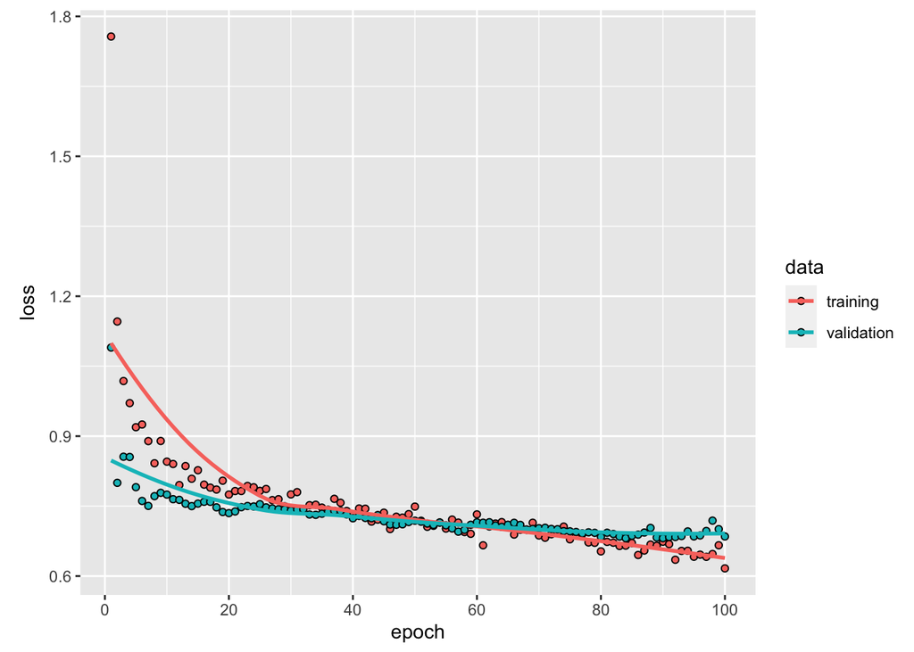

```r
plot(plot_model)
```

```r
cat("mse of simple NN model: ", mean((as.matrix(pred_y_nn)-as.matrix(y_test))^2))
```

```
mse of simple NN model:  0.7853728
```

**Complex Neural Network (using Train/Dev)**

```r
model_complex <- keras_model_sequential() %>%
    layer_dense(512, activation = 'relu', regularizer_l1_l2(l1=0.01,l2=0.01)) %>%
    layer_dropout(0.2) %>%
    layer_dense(128, activation = 'relu', regularizer_l1_l2(l1=0.01,l2=0.01)) %>%
    layer_dropout(0.2) %>%
    layer_dense(64, activation = 'relu', regularizer_l1_l2(l1=0.01,l2=0.01)) %>%
    layer_dropout(0.2) %>%
    layer_dense(32, activation = 'relu', regularizer_l1_l2(l1=0.01,l2=0.01)) %>%
    layer_dropout(0.2) %>%
    layer_dense(16, activation = 'relu', regularizer_l1_l2(l1=0.01,l2=0.01)) %>%
    layer_dropout(0.2) %>%
    layer_dense(8, activation = 'relu') %>%
    layer_dense(1)

model_complex %>% compile(
  loss = 'mean_absolute_error',
  optimizer = optimizer_adam()
)

plot_model <- model_complex %>% fit(as.matrix(X_train),
      as.matrix(y_train),
      epochs = 85,
      validation_split = 0.1,
      verbose = 0)

pred_y_nn_complex <- predict(model_complex, as.matrix(X_test))
```

```
2/2 - 0s - 71ms/epoch - 35ms/step
```

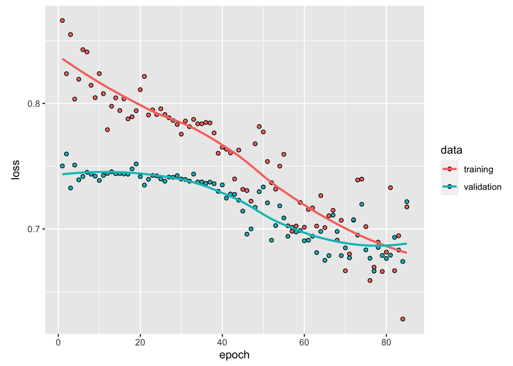

```r
plot(plot_model)
```

```r
cat("mse of complex NN model: ", mean((as.matrix(pred_y_nn_complex)-as.matrix(y_test))^2))
```

```
mse of complex NN model:  0.7449585
```

**XGBoost**

```r
xgb_train = xgb.DMatrix(data = as.matrix(X_train), label = as.matrix(y_train))
xgb_test = xgb.DMatrix(data = as.matrix(X_test), label = as.matrix(y_test))

watchlist = list(train=xgb_train, test=xgb_test)
xgb_model = xgb.train(data = xgb_train, max.depth = 3, watchlist=watchlist, nrounds = 10,verbose=1)
```

[output not shown]

```r
model_xgboost = xgboost(data = xgb_train, max.depth = 3, nrounds = 5, verbose = 0)
pred_y_xgboost <- predict(model_xgboost,xgb_test)

cat("mse of xgboost model: ", mean((as.matrix(pred_y_xgboost)-as.matrix(y_test))^2))
```

```
mse of xgboost model:  0.6961323
```

**Mixed Model - XGBoost and Lasso Regression**

```r
combined_model <- (pred_y_xgboost + pred_y_lasso) / 2

cat("mse of combined model: ", mean((as.matrix(combined_model)-as.matrix(y_test))^2))
```

```
mse of combined model:  0.6850406
```

**Support Vector Machine (SVM)**

```r
svm_model <- svm(x = X_train, y = y_train, kernel = "radial", cost = 1)
pred_y_svm <- predict(svm_model, newdata = X_test)
cat("mse of SVM model: ", mean((as.matrix(pred_y_svm)-as.matrix(y_test))^2))
```

```
mse of SVM model:  0.7826527
```